# Stochastic_Simulation

Stochastic differential equation (SDE) models play a prominent role in a range of application areas, however, a complete understanding of SDE theory requires a substantial background in advanced probability and stochastics which is quite daunting as well as time-consuming. From an application standpoint, I have found that numerical simulation of SDEs is often sufficient in providing the necessary intuition for the specific application and it also serves as the first step towards understanding the underlying SDE theory.

### What is a stochastic differential equation?

Consider a model of a phenomenon which is affected by d random sources say $W^1$, $W^2$, $W^3$,..., $W^d$, which are Wiener processes; independent, continous and nowhere differentiable functions of time. The sensitivity of model to each of these sources are recorded through the variables $V_1$, $V_2$, $V_3$, ..., $V_d$ while $V_0$ represents the deterministic part of the model. Then the model can be represented by

$$ dy = V_0(y, t) dt + V_1(y, t) dW^1 + V_2(y, t) dW^2 + ... + V_d(y, t) dW^d $$

Note that each of the random sources and the variable $y$ can be both a scalar or a vector. For example, if we are modelling a single stock price then $y$ and the random sources are also scalar, while if we are modelling multiple variable at the same time (like the yield curve or forward curve) then both $y$ and the random sources are vectors.

Another important point to note is that Wiener process is continous, thus $y(t)$ is also going to be continous.

### What are we trying to gain from an SDE and its simulation ?

Let the time interval of interest for us be $[0, T]$ and the initital state be $y_0$, then note that the future evolution of the system is uncertain. There can be multiple different ways the system evolves from its initial state $y_0$ over the inverval $[0, T]$. Let us denote an arbitary realization as $\omega$ which corresponds to the Wiener path $W(\omega)$ and the output $y_t(\omega)$ over the interval $[0, T]$.

Most often our objective is to evaluate functions $ f $ of the solution at a given point in time or along the entire path, $ f(t, y_s; s\le {t}) $. Once we have computed the function across the multiple paths, we are then interested in some statisitics like (mean, median, variance, percentile etc.) of the resulting function values evaluated across each realization $\omega$. For example, we might want to evluate $$ E[f(y_t)] = \int {f(y_t(\omega)) dP(\omega)} $$

where P is a probability measure and by choosing f to be of exponential form we can calculate all the moments of $y_t$ at a given time $t$. To retrieve this information using simulation, there are 2 main approaches:

1. Solve a partial differential equation obtained through the Feynman-Kac formulae. (I intend to do another post on the PDE approach)
2. Perform Monte-carlo simulation

In *Monte-Carlo simulation*, we generate a suitable number of sample paths $\hat{W} := ({\hat{W}}^1(\omega), {\hat{W}}^2(\omega), ..., {\hat{W}}^d(\omega))$ on $[0, T]$ where $\omega$ belongs to large but finite set. For each sample path $\hat{W}(\omega)$, we generate the solution of the SDE $\hat{y}(\omega)$ and compute the function $f(\hat{y_t})$. We can then compute $$E[f(\hat{y_t})] = \frac{\sum_{\omega}{f(\hat{y_t}(\omega))}}{\lvert \omega \rvert}$$

where ${\lvert \omega \rvert}$ is the total number of paths

### Strong and Weak Approximation

Another point of note before we delve into actual code, is the concept of strong and weak approximations for a SDE. Intuitivey, strong and weak approximations have to do with the decay of error rate of the actual process and the discrete simulation. As mentioned above, we are mostly interested in evaluation functions of the solution of the SDE. In such a scenario, we can define error of approximation in two different ways

1. $ E \lVert {y_t - \hat{y}_t} \rVert $, this allows us to compare the simulated path to the actual path.
2. $ E \lVert {f(y_t) - f(\hat{y}_t)} \rVert $, this allows us to compare the value of the function from the simulation to that of the actual function value

Clearly, if $ E \lVert {y_t - \hat{y}_t} \rVert $ is sufficiently small, then $ E \lVert {f(y_t) - f(\hat{y}_t)} \rVert $ is also going to be small, however, the inverse is not necessary. Therefore, the first measure of error is used to define a *strong approximation* while the second definition is used to define a *weak approximation*. Specifically,

1. Strong Approximation is equivalent to saying $ E \lVert {y_t - \hat{y}_t} \rVert $ is sufficiently small. The rate of decay of this error is quantified using the *strong order of convergence* . A method is said to have a **strong order of convergence** equal to $\gamma$ if there exists a constant C such that $$ E \; {\lVert {y_t - \hat{y}_t} \rVert} \le {C \ \delta t^{\gamma}}$$
2. Weak Approximation is equivalent to saying $ E \lVert {f(y_t) - f(\hat{y}_t)} \rVert $ is sufficiently small. The rate of decay of this error is quantified using the *weak order of convergence* . A method is said to have a **weak order of convergence** equal to $\gamma$ if there exists a constant C such that for all functions $f$ in some class $$ E \; {\lVert {f(y_t) - f(\hat{y}_t)} \rVert} \le {C \ \delta t^{\gamma}} $$

where $\delta t$ is the time step of the simulation.

### The working horse: Brownian motion or Wiener Process

A scalar standard Brownian motion, or a standard Weiner process, over $[0,T]$ is a random variable W(t) that depends continously on $t$ that $t \in [0,T]$ and satisfies the following conditions:

1. $W(0)=0$ with probability 1
2. For $ 0 \le s \lt t \le T$ the random variable given by difference $W(t)-W(s)$ is normally distributed with mean 0 and variance $t-s$, or $W(t)-W(s) \sim \sqrt{t-s}N(0,1)$, where $N(0,1)$ is normal distribution with zero mean and unit variance.
3. $ 0 \le s \lt t \le u \lt v \le T$, the increments $ W(t) - W(s) $ and $ W(v) - W(u) $ are independent.

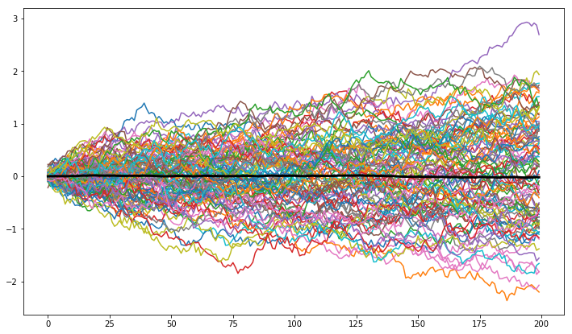

```python
%matplotlib inline

import numpy as np
import matplotlib.pyplot as plt

def simulate_wiener_path(num_paths, path_length, T=1):
    dt = T / path_length
    dW = np.sqrt(dt) * np.random.randn(num_paths, path_length)
    W = np.cumsum(dW, axis=1)
    return W

# Simulate 1000 paths of the wiener process and calculate the mean
sample_paths = simulate_wiener_path(1000, 200)
mean_path = np.mean(sample_paths, axis=0)

# Plot the mean and the first 100 paths
plt.figure(figsize=(12, 7))
_ = plt.plot(sample_paths.T[:, :100])
_ = plt.plot(mean_path, color='black', lw=3)
```

### Simulation of SDEs

We consider simulation of SDEs of the Ito form in this post $$ dy_t = \mu(y_t, t) \ dt + \sigma(y_t, t) \ dW_t $$

where $\mu(y_t, t)$ is called the *drift coefficient*, that is the deterministic part of the SDE characterizing the local trend. The second term $\sigma(y_t, t)$ denotes the *diffusion coefficient* that represents the variance (average size) of the fluctations of the solution $y_t$.

The most widely used methods to simulate $y_t$ by numerically integrating the above SDE are introduced below

- order 0.5 strong Taylor Scheme: Euler-Maruyama
- order 1.0 strong Taylor Scheme: Milstein and derivative-free Milstein (Runge-Kutta)
- order 1.5 strong Taylor scheme
- order 2 weak Taylor scheme
- order 2 weak Runge-Kuta scheme

### Setup

To demonstrate each of the methods we will apply the methods to the following linear SDE

$$ dy_t = \mu y_t \ dt + \sigma y_t \ dW_t, \; \; y_0 = 1 \; and \; t \in [0, T] , \; \; \mu=1, \sigma=1$$

This is the Geometric Brownian Model used for modelling of the price process in Black-Scholes model. The exact solution to this SDE is knownn and is given by

$$ y_t = y_0 \ exp((\mu - \frac{1}{2} \sigma^2)t + \sigma \ W_t) $$

Further, instead of copying and pasting a lot of the code. I have created the following boiler plate code that will be reused throughout the post. I have created a *DiffusionBase* object, which accepts an arbitary function for drift, diffusion and approximation / iteration function.

Using the object, you can then simulate multiple realization of the solution using the *obj.simulate_paths(num_paths, T=1, y0=1)* method. If you have access to the exact solution of the form *f(y0, W, t)* then, we can use this exact solution to compute path errors and plot simulation/approximation diagnosis plots using the *obj.path_error(exact_simulation)* and *obj.plot_path_and_error(exact_simulation)* respectively.

```python
# Boiler plate code
from itertools import accumulate
import numpy as np
import matplotlib.pyplot as plt
import inspect
from types import SimpleNamespace
from sympy import *


class DiffusionBase:
    def __init__(self, drift, diffusion, approximation_func, seed=100):
        self.drift = drift
        self.diffusion = diffusion
        self.d_diffusion = self.get_derivatives(self.diffusion, 1)
        self.d_drift = self.get_derivatives(self.drift, 1)
        self.dd_diffusion = self.get_derivatives(self.diffusion, 2)
        self.dd_drift = self.get_derivatives(self.drift, 2)
        self.iteration_method = approximation_func
        self.rng = np.random.RandomState(seed)

    def simulate_paths(self, num_paths, path_length, T=1, y0=1):
        h = T / path_length
        t = np.linspace(0, T, path_length + 1)

        iteration_method = lambda prev, x: self.iteration_method(prev, x, h, self)

        # Wiener Path realizations
        dW = self.rng.randn(num_paths, path_length) * np.sqrt(h)
        W = np.hstack((np.zeros((num_paths, 1)), np.cumsum(dW, axis=1)))

        # apply the iteration on each Wiener path realization, I am using the python function accumulate to implement the iteration.
        em_paths = np.array([list(accumulate(np.append([y0], p), iteration_method)) for p in dW])

        return em_paths, W, t

    def get_derivatives(self, func, order):
        arg_symbols = symbols(list(inspect.signature(drift).parameters.keys()))
        sym_func = func(*arg_symbols)

        return [lambdify(arg_symbols, sym_func.diff(a, order)) for a in arg_symbols][0]

    def path_error(self, exact_solution, log_10_max_grid_points=5):
        N = 10 ** np.arange(log_10_max_grid_points)
        errs = []
        time_step = []

        p_thresh = np.linspace(0, 0.9, 10)
        errs_cond_percentile = []

        num_paths = 1000
        T = 1
        y0 = 1

        for n in N:
            # print(' --- computing errors for grid points %s' % n)
            em_paths, W, t = self.simulate_paths(num_paths, n, T, y0)
            exact_paths = exact_solution(y0, W, t)
            # compute path errors
            err = np.mean(np.sqrt(np.mean((em_paths - exact_paths) ** 2, axis=1)))
            errs.append(err)
            time_step.append(T / n)
            # compute path errors for each percentile thresh
            perc_err = []
            for p in p_thresh:
                terminal = em_paths[:, -1]
                thresh = np.percentile(terminal, p * 100)
                err = np.mean(
                    np.sqrt(np.mean((em_paths[terminal >= thresh] - exact_paths[terminal >= thresh]) ** 2, axis=1)))
                perc_err.append(err)
            errs_cond_percentile.append(perc_err)
        return {'path_errors': errs, 'time_step':time_step, 'percentile_levels':p_thresh, 'conditional_errors':errs_cond_percentile}

    def plot_path_and_error(self, exact_solution, plot=True, log10_max_grid_points=5):
        num_paths = 100
        y0=1
        T=1

        em_paths_to_plot, W, t = self.simulate_paths(num_paths, 100, T, y0)
        exact_paths_to_plot = exact_solution(1, W, t)

        res = self.path_error(exact_solution, log_10_max_grid_points=log10_max_grid_points)
        time_step = res['time_step']
        errs = res['path_errors']
        p_thresh = res['percentile_levels']
        errs_cond_percentile = res['conditional_errors']

        self.temp_results = SimpleNamespace(y0=y0, T=T, num_paths=num_paths, approx_paths=em_paths_to_plot,
                                            W=W, t=t, exact_paths=exact_paths_to_plot,
                                            errs={'time_step':time_step, 'errs':errs},
                                            cond_errs={'percentile':p_thresh, 'conditional_errors':errs_cond_percentile})
        # Plot log(paths errors) vs. log(time step)
        if plot:
            plt.figure(figsize=(20, 10))

            # ----------------------------------------------------------------------------------------------
            # Let's plot the sample paths to see the difference between the exact solution and EM approximation.
            # ----------------------------------------------------------------------------------------------
            plt.subplot(221)
            plt.plot(em_paths_to_plot.T, linestyle='--')
            plt.plot(em_paths_to_plot.mean(axis=0), color='black', lw=2, linestyle='-', label='cross-sectional mean')
            plt.title('Sample paths from the iteration scheme')
            plt.legend(loc=0)

            plt.subplot(222)
            colormap = plt.cm.gist_ncar
            colors = [colormap(i) for i in np.linspace(0, 0.9, 5)]

            for i, p_i in enumerate(self.rng.randint(0, num_paths - 1, 5)):
                _ = plt.plot(em_paths_to_plot[p_i], color=colors[i], linestyle='-')
                _ = plt.plot(exact_paths_to_plot[p_i], color=colors[i], linestyle='-.', lw=2)
            plt.title('Comparison of the exact solution to the approximation (- Approx, -. Exact)')

            fit = np.polyfit(np.log(time_step), np.log(errs), 1)
            fit_fn = np.poly1d(fit)

            plt.subplot(223)
            plt.plot(np.log(time_step), np.log(errs), 'b-')
            eqn = '$ y=%sx %s %s $' % (
            np.round(fit[0], 3), '-' if np.sign(np.round(fit[1], 3)) == -1 else "+", np.abs(np.round(fit[1], 3)))
            plt.plot(np.log(time_step), fit_fn(np.log(time_step)), 'k--', label=eqn)
            plt.ylabel('$log( \ E \ (\mid {y_t - \hat{y}_t} \mid)$')
            plt.xlabel('$log(\Delta T)$')
            plt.title('Path errors vs. Time step')
            plt.legend()

            # Plot
            plt.subplot(224)
            plt.plot(p_thresh, np.log(errs_cond_percentile[0]), label='time_step: %s' % time_step[0])
            plt.plot(p_thresh, np.log(errs_cond_percentile[1]), label='time_step: %s' % time_step[1])
            plt.plot(p_thresh, np.log(errs_cond_percentile[2]), label='time_step: %s' % time_step[2])
            plt.ylabel('$log( \ E \ ((\mid {y_t - \hat{y}_t} \mid) )$')
            plt.xlabel('percentile')
            plt.title('Conditional Path error vs. percentile of terminal distribution')
            plt.legend(loc=0)

            plt.tight_layout(h_pad=3, w_pad=3)
            plt.show()
```

### Euler-Maruyama Method (0.5 order strong)

This is the simplest numerical approximation and considers only first order terms. The iterative scheme for EM is given by

$$ \begin{array}{1} y_{n+1} = y_n + \mu(y_n, t_n) \ \Delta t_n + \sigma(y_n, t_n) \ \Delta W_n \\ y_0 = y0 \\ n = 0, 1, 2, ..., N-1 \\ \Delta W = (W_{n+1} - W_n) \sim \sqrt{h} \mathscr{N} (0,1) \\ h = t_{n+1} - t_{n} \end{array} $$

As the order of convergence of this method is low, the numerical errors are inaccurate unless a very small time step is used.

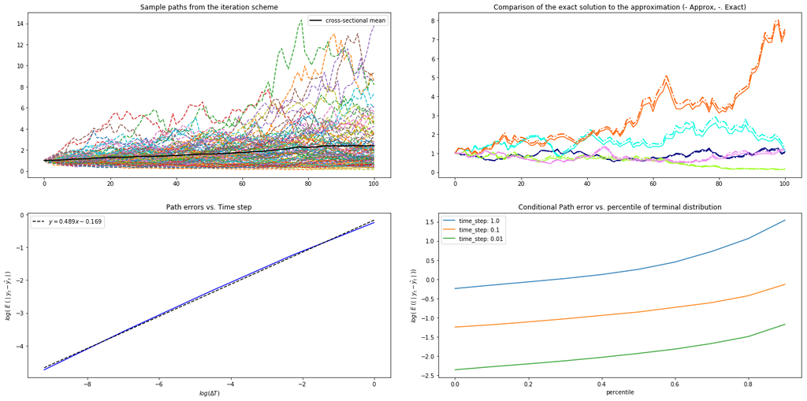

```python
drift = lambda x: x
diffusion = lambda x: x
advance = lambda y_t, dW, dt, obj: y_t + obj.drift(y_t) * dt + obj.diffusion(y_t) * dW  #obj is of type DiffusionBase
exact_solution = lambda y0, W, t: y0 * np.exp(0.5*t + W)

objEuler = DiffusionBase(drift, diffusion, advance)  # Boiler plate object for all the analysis
objEuler.plot_path_and_error(exact_solution)
```

The above chart plots EM approximation along with the exact solution. The approximation is obviously not exact as expected, however, there are two main observations

1. the approximations become more accurate as the number of grid point increases ($\Delta T \to 0 $). By the property of 0.5 order of strong convergence of the EM method, we expect $E \; {\lVert {f(y_t) - f(\hat{y}_t)} \rVert} \le {C \ \Delta t^{0.5}}$. If this inequality holds with approximate equality, then taing logs on both side we have, $$ log \ path\_err_{\Delta t} \approx logC + \frac{1}{2} log \Delta t $$This is what is demonstrated in the bottom left chart. The equation of the regression line is shown in the legend and can be used to determine C.
2. Next, observe that the error of approximation tends to be more for extrema paths - paths containing points which are far from the cross-sectional mean. The bottom right chart plots $$ E(\lVert {y_t - \hat{y}_t} \rVert \; \lvert \; y_T > p^{th} \ percentile \ of \ terminal \ distribution) \; \; vs. \; \; p$$, the path error conditional on the path ending above $p^{th}$ percentile of the terminal distribution of the paths. As the time step decreases the overall error diminishes as expected, but the errors tend to increase rapidly as the path moves away from the cross sectional mean. This suggests that if we are trying to estimate or study the extrema (for example, expected highs / lows and tail properties of the cross-sectional distribution), we need a large the number of grid points.

### Milstein Method (1.0 order strong)

The Milstein method is a 1.0 order strong iteration scheme that is constructed by including higher order terms from the Ito-Taylor stochastic expasion. The iterative scheme for Milstein method is given by

$$ \begin{array}{1} y_{n+1} = y_n + \mu(y_n, t_n) \ \Delta t_n + \sigma(y_n, t_n) \ \Delta W_n + \frac{1}{2} \sigma(y_n, t_n) \ \partial_{y} \ \sigma(y_n, t_n) \ ({\Delta W_n}^2 - \Delta t_n)\\ y_0 = y0 \\ n = 0, 1, 2, ..., N-1 \\ \Delta W = (W_{n+1} - W_n) \sim \sqrt{h} \mathscr{N} (0,1) \\ h = t_{n+1} - t_{n} \end{array} $$

The first 3 terms of the iteration scheme is same as that of the EM method, with the 4th terms encapsulating the higher order effects. As the order of convergence of this method is 1.0, the numerical errors are inaccurate unless a very small time step is used.

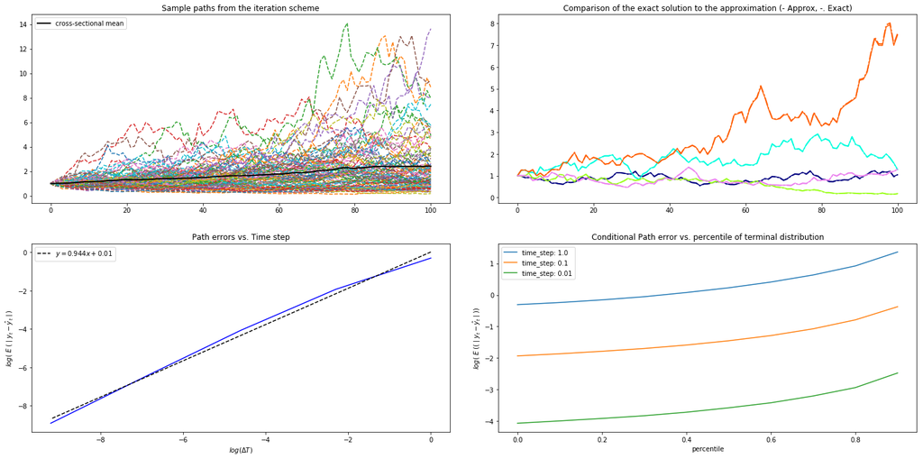

```python
drift = lambda x: x
diffusion = lambda x: x
advance = lambda y_t, dW, dt, obj: y_t + obj.drift(y_t) * dt + obj.diffusion(y_t) * dW  + \
                                    0.5 * obj.diffusion(y_t) * obj.d_diffusion(y_t) * (dW**2 - dt)
exact_solution = lambda y0, W, t: y0 * np.exp(0.5*t + W)

objDiffusion = DiffusionBase(drift, diffusion, advance)  # Boiler plate object for all the analysis
objDiffusion.plot_path_and_error(exact_solution)
```

I have used the same seed for the simulation so that a direct visual comparison can be made between the two plots. The top left charts have the same paths in both cases and the exact paths in the top right are also the same same in both cases. It is clear from a glance at the top right chart in both cases, that the milstein method is more accurate than the euler murayama method as expected.

The bottom left chart (log(path err) vs. log(time step)) reflects the 1.0 strong order of convergence, with the slope of the line $\approx 1$. The bottom right chart, however, show a similiar shape suggesting that a proper study of extrema of SDE, require simulation at a much smaller value of the time-step.

### Derivative Free Milstein Method (1.0 order strong)

This is the derivative free version of Milstein method which is implemented by the use of Runge-Kutta method. The iterative scheme for Runge-Kutta method is given by

$$ \begin{array}{1} y_{n+1} = y_n + \mu(y_n, t_n) \ \Delta t_n + \sigma(y_n, t_n) \ \Delta W_n + \frac{1}{2} (\sigma(y_n + \sigma(y_n) \sqrt{\Delta t_n}) - \sigma(y_n)) \ \frac{({\Delta W_n}^2 - \Delta t_n)}{\sqrt{\Delta t_n}}\\ y_0 = y0 \\ n = 0, 1, 2, ..., N-1 \\ \Delta W = (W_{n+1} - W_n) \sim \sqrt{h} \mathscr{N} (0,1) \\ h = t_{n+1} - t_{n} \end{array} $$

As the order of convergence of this method is 1.0, the numerical errors are inaccurate unless a very small time step is used.

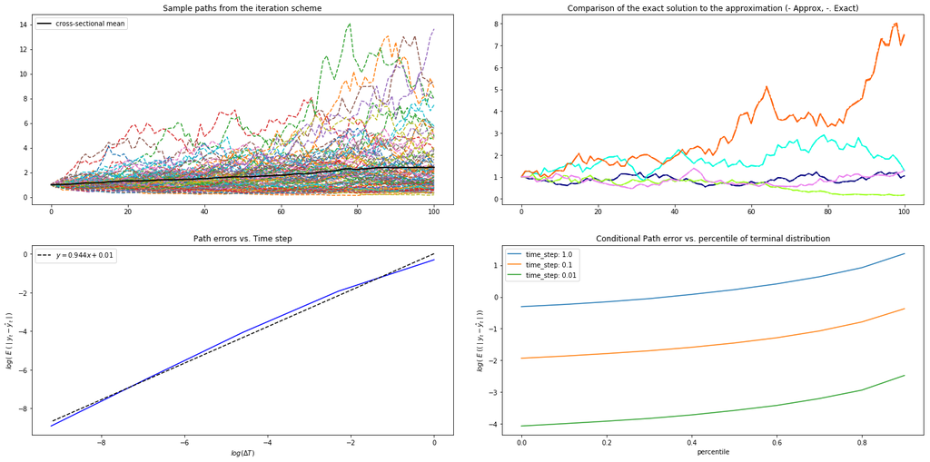

```python
drift = lambda x: x
diffusion = lambda x: x
advance = lambda y_t, dW, dt, obj: y_t + obj.drift(y_t) * dt + obj.diffusion(y_t) * dW  + \
          0.5 * (obj.diffusion(y_t + obj.diffusion(y_t)*np.sqrt(dt)) - obj.diffusion(y_t)) * (dW**2 - dt) / np.sqrt(dt)
exact_solution = lambda y0, W, t: y0 * np.exp(0.5*t + W)

objDiffusion = DiffusionBase(drift, diffusion, advance)  # Boiler plate object for all the analysis
objDiffusion.plot_path_and_error(exact_solution)
```

### 1.5 order strong Taylor method

This method is contructred using even higher order terms from the stochastic expansion. The iterative scheme is given by

$$ \begin{array}{1} \begin{align} y_{n+1} = y_n + \mu \ \Delta t_n + \sigma \ \Delta W_n + \frac{1}{2}\sigma \sigma_y \ ({\Delta W_n}^2 - \Delta t_n) \; +\\ \mu_{y} \sigma \ \Delta Z_n + \frac{1}{2} (\mu \mu_y + \frac{1}{2} \sigma^2 \mu_{yy}) \ \Delta t_n^2 \; + \\ (\mu \sigma_y + \frac{1}{2} \sigma^2 \sigma_{yy}) \ (\Delta W_n \Delta t_n - \Delta Z_n) \; + \\ \frac{1}{2} \sigma \ (\sigma \sigma_{yy} + \sigma_y^2) \ (\frac{1}{3} {\Delta W_n}^2 - \Delta t_n) \Delta W_n \end{align} \\ y_0 = y0 \\ n = 0, 1, 2, ..., N-1 \\ \Delta Z = \frac{1}{2} \ h \ (\Delta W + \frac{\Delta V}{\sqrt{3}})\\ \Delta W = (W_{n+1} - W_n) \sim \sqrt{h} \mathscr{N} (0,1) \\ \Delta V \sim \sqrt{h} \mathscr{N} (0,1) \\ h = t_{n+1} - t_{n} \end{array} $$

As the order of convergence of this method is 1.5, this is suitable only when we require very accurate results about the paths.

Whether higher-order methods are needed in a given application depends on how the resulting approximate solutions are to be used. In the ordinary differential equation case, the usual assumption is that the initial condition and the equation are known with accuracy. Then it makes sense to calculate the solution as closely as possible to the same accuracy, and higher order methods are called for. In the context of SDEs, in particular if the initial conditions are chosen from a probability distribution, the advantages of higher order solvers are often less compelling, and if they come with added computational expense, may not be warranted

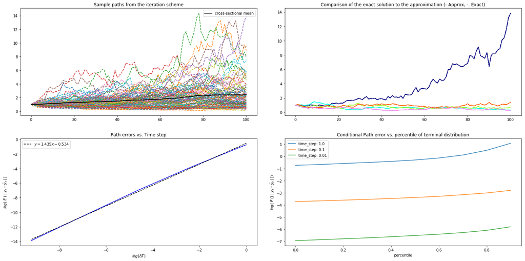

```python
drift = lambda x: x
diffusion = lambda x: x
advance = lambda y_t, dW, dt, obj: y_t + obj.drift(y_t) * dt + obj.diffusion(y_t) * dW  + \
          0.5 * (obj.diffusion(y_t + obj.diffusion(y_t)*np.sqrt(dt)) - obj.diffusion(y_t)) * (dW**2 - dt) / np.sqrt(dt)

def advance(y_t, dW, dt, obj):
    dV = obj.rng.randn() * np.sqrt(dt)
    dZ = 0.5 * dt * (dW + dV/np.sqrt(3))
    mu = obj.drift(y_t)
    sigma = obj.diffusion(y_t)
    mu_y = obj.d_drift(y_t)
    sigma_y = obj.d_diffusion(y_t)
    mu_yy = obj.dd_drift(y_t)
    sigma_yy = obj.dd_diffusion(y_t)
    y_next = y_t + mu * dt + sigma * dW + 0.5 * sigma * sigma_y * (dW**2 - dt) + mu_y * sigma * dZ + \
            0.5*(mu * mu_y + 0.5 * sigma**2 * mu_yy) * dt**2 + (mu * sigma_y + 0.5 * sigma**2 * sigma_yy)*(dW*dt - dZ) + \
            0.5 * sigma * (sigma*sigma_yy + sigma_y**2) *(1/3*dW**2 - dt) * dW
    return y_next

exact_solution = lambda y0, W, t: y0 * np.exp(0.5*t + W)

objDiffusion = DiffusionBase(drift, diffusion, advance)  # Boiler plate object for all the analysis
objDiffusion.plot_path_and_error(exact_solution)
```